# Work Integrated Learning Programmes Division M.Tech (Data Science and Engineering) Data Visualization And Interpretation (DSECL ZG555)) Second Semester, 2021-22

## Assignment 2 – PS2 [Weightage 13%]

1. Do not change the name of the data file that is shared with the problem statement.
2. If intermediate data files are created, retain in the present working directory and attach them during submission.
3. Retain the data file in the same directory as that of this workbook.
4. Retain the Visualizations that is produced in the file. Don't clear them away.
5. All the visuals should adhere to the visualization principles learnt in the Course and must be presentation ready.Most effective visuals would fetch maximum credits
6. Submissions done via means other than CANVAS will strictly be NOT graded.

# Objective

#### Subscription prediction from the given dataset

## Group No: DVI Group 19

| Full Name | BITS ID |
| --- | --- |
| GOYAL TARUCHIT TARUN CHITRA | 2022DC04496 |
| AKASH CHOUDHARY | 2022DC04243 |
| KARTHIKEYAN D | 2022DC04197 |

## Download and Prep the Data: 1 Mark

Import the modules needed

```python
import pandas as pd
import numpy as np
from matplotlib import pyplot as plt
import seaborn as sns
```

Download the dataset and read it into a dataframe

```python
subscription_dataset=pd.read_csv('dvi-a2-ps2-data.csv')
```

First five items in the dataset.

```python
subscription_dataset.head(5)
```

|  | age | job | marital | education | default | housing | loan | contact | month | day_of_week | ... | campaign | pdays | previous | poutcome | emp_var_rate | cons_price_idx | cons_conf_idx | euribor3m | nr_employed | subscription |
| --- | --- | --- | --- | --- | --- | --- | --- | --- | --- | --- | --- | --- | --- | --- | --- | --- | --- | --- | --- | --- | --- |
| 0 | 44 | blue-collar | married | basic.4y | unknown | yes | no | cellular | aug | thu | ... | 1 | 999 | 0 | nonexistent | 1.4 | 93.444 | -36.1 | 4.963 | 5228.1 | 0 |
| 1 | 53 | technician | married | unknown | no | no | no | cellular | nov | fri | ... | 1 | 999 | 0 | nonexistent | -0.1 | 93.200 | -42.0 | 4.021 | 5195.8 | 0 |
| 2 | 28 | management | single | university.degree | no | yes | no | cellular | jun | thu | ... | 3 | 6 | 2 | success | -1.7 | 94.055 | -39.8 | 0.729 | 4991.6 | 1 |
| 3 | 39 | services | married | high.school | no | no | no | cellular | apr | fri | ... | 2 | 999 | 0 | nonexistent | -1.8 | 93.075 | -47.1 | 1.405 | 5099.1 | 0 |
| 4 | 55 | retired | married | basic.4y | no | yes | no | cellular | aug | fri | ... | 1 | 3 | 1 | success | -2.9 | 92.201 | -31.4 | 0.869 | 5076.2 | 1 |

5 rows × 21 columns

Find out how many entries there are in the dataset.

```python
len(subscription_dataset.index)
```

```
41188
```

Clean up data.  
Remove unnecessary columns. Mention the reasons.  
Show the data.

```python
#Fetching empty rows in the dataset
subscription_dataset.isna().sum()
```

```
age               0
job               0
marital           0
education         0
default           0
housing           0
loan              0
contact           0
month             0
day_of_week       0
duration          0
campaign          0
pdays             0
previous          0
poutcome          0
emp_var_rate      0
cons_price_idx    0
cons_conf_idx     0
euribor3m         0
nr_employed       0
subscription      0
dtype: int64
```

```python
subscription_dataset.isnull().sum()
```

```
age               0
job               0
marital           0
education         0
default           0
housing           0
loan              0
contact           0
month             0
day_of_week       0
duration          0
campaign          0
pdays             0
previous          0
poutcome          0
emp_var_rate      0
cons_price_idx    0
cons_conf_idx     0
euribor3m         0
nr_employed       0
subscription      0
dtype: int64
```

**There are no null values in the dataset.**

```python
#Checking datatype of each field
subscription_dataset.dtypes
```

```
age                 int64
job                object
marital            object
education          object
default            object
housing            object
loan               object
contact            object
month              object
day_of_week        object
duration            int64
campaign            int64
pdays               int64
previous            int64
poutcome           object
emp_var_rate      float64
cons_price_idx    float64
cons_conf_idx     float64
euribor3m         float64
nr_employed       float64
subscription        int64
dtype: object
```

```python
#We observed that for pdays, there are three types of values: -
#999: Not contacted, thus it can be considered same as number of previous contacts=zero.
#Any other positive value: Number of previous contacts
```

```python
i=0
while(i<len(subscription_dataset['pdays'])):
    if(subscription_dataset['pdays'][i]==999):
        subscription_dataset.iat[i, 12]=0
    i=i+1
```

```python
subscription_dataset.head()
```

|  | age | job | marital | education | default | housing | loan | contact | month | day_of_week | ... | campaign | pdays | previous | poutcome | emp_var_rate | cons_price_idx | cons_conf_idx | euribor3m | nr_employed | subscription |
| --- | --- | --- | --- | --- | --- | --- | --- | --- | --- | --- | --- | --- | --- | --- | --- | --- | --- | --- | --- | --- | --- |
| 0 | 44 | blue-collar | married | basic.4y | unknown | yes | no | cellular | aug | thu | ... | 1 | 0 | 0 | nonexistent | 1.4 | 93.444 | -36.1 | 4.963 | 5228.1 | 0 |
| 1 | 53 | technician | married | unknown | no | no | no | cellular | nov | fri | ... | 1 | 0 | 0 | nonexistent | -0.1 | 93.200 | -42.0 | 4.021 | 5195.8 | 0 |
| 2 | 28 | management | single | university.degree | no | yes | no | cellular | jun | thu | ... | 3 | 6 | 2 | success | -1.7 | 94.055 | -39.8 | 0.729 | 4991.6 | 1 |
| 3 | 39 | services | married | high.school | no | no | no | cellular | apr | fri | ... | 2 | 0 | 0 | nonexistent | -1.8 | 93.075 | -47.1 | 1.405 | 5099.1 | 0 |
| 4 | 55 | retired | married | basic.4y | no | yes | no | cellular | aug | fri | ... | 1 | 3 | 1 | success | -2.9 | 92.201 | -31.4 | 0.869 | 5076.2 | 1 |

5 rows × 21 columns

```python
#Checking datatype of each field after above operation
subscription_dataset.dtypes
```

```
age                 int64
job                object
marital            object
education          object
default            object
housing            object
loan               object
contact            object
month              object
day_of_week        object
duration            int64
campaign            int64
pdays               int64
previous            int64
poutcome           object
emp_var_rate      float64
cons_price_idx    float64
cons_conf_idx     float64
euribor3m         float64
nr_employed       float64
subscription        int64
dtype: object
```

```python
#Understanding the categorical features and their unique values
for col in subscription_dataset.select_dtypes(include='object').columns:
    print(col)
    print(subscription_dataset[col].unique())
```

```
job
['blue-collar' 'technician' 'management' 'services' 'retired' 'admin.'
 'housemaid' 'unemployed' 'entrepreneur' 'self-employed' 'unknown'
 'student']
marital
['married' 'single' 'divorced' 'unknown']
education
['basic.4y' 'unknown' 'university.degree' 'high.school' 'basic.9y'
 'professional.course' 'basic.6y' 'illiterate']
default
['unknown' 'no' 'yes']
housing
['yes' 'no' 'unknown']
loan
['no' 'yes' 'unknown']
contact
['cellular' 'telephone']
month
['aug' 'nov' 'jun' 'apr' 'jul' 'may' 'oct' 'mar' 'sep' 'dec']
day_of_week
['thu' 'fri' 'tue' 'mon' 'wed']
poutcome
['nonexistent' 'success' 'failure']
```

**Clean up of data**

- In column pdays, we had observed the rows where client was not previously contacted was having value as 999.
- Thus, we updated those rows with value=0 so that it correctly represents the number of calls for each client during previous campaign.

**Removal of unwanted columns**

1. We did not find any unwanted column in the dataset.
2. Reason: There is no column such as serial number, name of customer or another column which may not be required in data analysis.

**Showing the data**

```python
#Showing the data
subscription_dataset
```

|  | age | job | marital | education | default | housing | loan | contact | month | day_of_week | ... | campaign | pdays | previous | poutcome | emp_var_rate | cons_price_idx | cons_conf_idx | euribor3m | nr_employed | subscription |
| --- | --- | --- | --- | --- | --- | --- | --- | --- | --- | --- | --- | --- | --- | --- | --- | --- | --- | --- | --- | --- | --- |
| 0 | 44 | blue-collar | married | basic.4y | unknown | yes | no | cellular | aug | thu | ... | 1 | 0 | 0 | nonexistent | 1.4 | 93.444 | -36.1 | 4.963 | 5228.1 | 0 |
| 1 | 53 | technician | married | unknown | no | no | no | cellular | nov | fri | ... | 1 | 0 | 0 | nonexistent | -0.1 | 93.200 | -42.0 | 4.021 | 5195.8 | 0 |
| 2 | 28 | management | single | university.degree | no | yes | no | cellular | jun | thu | ... | 3 | 6 | 2 | success | -1.7 | 94.055 | -39.8 | 0.729 | 4991.6 | 1 |
| 3 | 39 | services | married | high.school | no | no | no | cellular | apr | fri | ... | 2 | 0 | 0 | nonexistent | -1.8 | 93.075 | -47.1 | 1.405 | 5099.1 | 0 |
| 4 | 55 | retired | married | basic.4y | no | yes | no | cellular | aug | fri | ... | 1 | 3 | 1 | success | -2.9 | 92.201 | -31.4 | 0.869 | 5076.2 | 1 |
| ... | ... | ... | ... | ... | ... | ... | ... | ... | ... | ... | ... | ... | ... | ... | ... | ... | ... | ... | ... | ... | ... |
| 41183 | 59 | retired | married | high.school | unknown | no | yes | telephone | jun | thu | ... | 1 | 0 | 0 | nonexistent | 1.4 | 94.465 | -41.8 | 4.866 | 5228.1 | 0 |
| 41184 | 31 | housemaid | married | basic.4y | unknown | no | no | telephone | may | thu | ... | 2 | 0 | 0 | nonexistent | 1.1 | 93.994 | -36.4 | 4.860 | 5191.0 | 0 |
| 41185 | 42 | admin. | single | university.degree | unknown | yes | yes | telephone | may | wed | ... | 3 | 0 | 0 | nonexistent | 1.1 | 93.994 | -36.4 | 4.857 | 5191.0 | 0 |
| 41186 | 48 | technician | married | professional.course | no | no | yes | telephone | oct | tue | ... | 2 | 0 | 0 | nonexistent | -3.4 | 92.431 | -26.9 | 0.742 | 5017.5 | 0 |
| 41187 | 25 | student | single | high.school | no | no | no | telephone | may | fri | ... | 4 | 0 | 0 | nonexistent | 1.1 | 93.994 | -36.4 | 4.859 | 5191.0 | 0 |

41188 rows × 21 columns

# Visualisation Questions - 2 X 5 = 10 Marks

### Question 1

#### Find the correlation and plot the correlation between features. Write the python code in the below cell to create appropriate visual to perform the above task.

We have taken median values as our average in below charts because mean has disadvantage of giving incorrect results in skewed distribution of data.

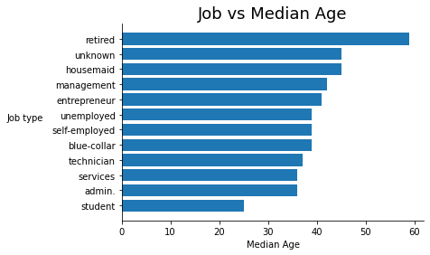

```python
#Plotting Job vs Median Age
median_age_by_job = subscription_dataset.groupby('job')['age'].median()
sorted_median_age_by_job = median_age_by_job.sort_values()
sorted_median_age_by_job
job_medianAge = pd.DataFrame({'job': sorted_median_age_by_job.index, 'median_age': sorted_median_age_by_job.values})
plt.barh(job_medianAge['job'],job_medianAge['median_age'])
plt.title("Job vs Median Age",fontsize=18)
plt.xlabel('Median Age')
plt.ylabel('Job type',rotation=0,labelpad=30)
ax=plt.gca()
ax.spines['top'].set_visible(False)
ax.spines['right'].set_visible(False)
plt.show()
```

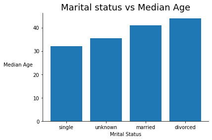

```python
#Plotting Marital Status vs Median Age
median_age_by_marital = subscription_dataset.groupby('marital')['age'].median()
sorted_median_age_by_marital = median_age_by_marital.sort_values()
#sorted_median_age_by_marital
marital_medianAge = pd.DataFrame({'marital': sorted_median_age_by_marital.index, 'median_age': sorted_median_age_by_marital.values})
plt.bar(marital_medianAge['marital'],marital_medianAge['median_age'])
plt.title("Marital status vs Median Age", fontsize=18)
plt.xlabel('Mrital Status')
plt.ylabel('Median Age',rotation=0,labelpad=30)
ax=plt.gca()
ax.spines['top'].set_visible(False)
ax.spines['right'].set_visible(False)
plt.show()
```

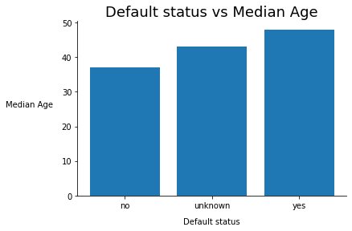

```python
#Plotting Default vs Median Age
median_age_by_default = subscription_dataset.groupby('default')['age'].median()
sorted_median_age_by_default = median_age_by_default.sort_values()
#sorted_median_age_by_default
default_medianAge = pd.DataFrame({'default': sorted_median_age_by_default.index, 'median_age': sorted_median_age_by_default.values})
plt.bar(default_medianAge['default'],default_medianAge['median_age'])
plt.title("Default status vs Median Age",fontsize=18)
plt.xlabel('Default status',labelpad=10)
plt.ylabel('Median Age',rotation=0,labelpad=40)
ax=plt.gca()
ax.spines['top'].set_visible(False)
ax.spines['right'].set_visible(False)
plt.show()
```

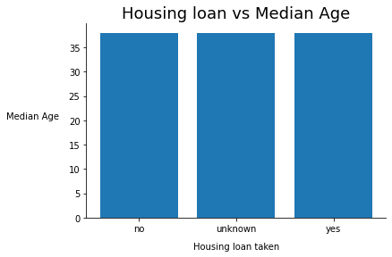

```python
#Plotting Housing vs Median Age
median_age_by_housing = subscription_dataset.groupby('housing')['age'].median()
sorted_median_age_by_housing = median_age_by_housing.sort_values()
#sorted_median_age_by_housing
housing_medianAge = pd.DataFrame({'housing': sorted_median_age_by_housing.index, 'median_age': sorted_median_age_by_housing.values})
plt.bar(housing_medianAge['housing'],housing_medianAge['median_age'])
plt.title("Housing loan vs Median Age",fontsize=18)
plt.xlabel('Housing loan taken',labelpad=10)
plt.ylabel('Median Age',rotation=0,labelpad=40)
ax=plt.gca()
ax.spines['top'].set_visible(False)
ax.spines['right'].set_visible(False)
plt.show()
```

**Summary of the findings: -**

- Among working professionals, on average: -

  1.1 Housemaid have highest age.

  2.1 For customers with marital status=divorced, average age is around 45.

  2.2 For customers, with marital status=married average age is around 40.

  3.1 Average age of customers who committed default is higher than average age of customers did not commit the default.

  3.2 There are some customers whose Default status is unknown, but their average age is around 42 years.
- There is no correlation among the customers who have opted for Housing loan and their average age.

**Reasons for selecting the chart type: -**

- Bar chart was used to visualize the relation between various categorical features and Median age of the customers.
- Bar chart is useful to compare discrete categories of data in the dataset.
- In Job vs Median Age, Horizontal Bar chart was chosen because the number of categories were more, and plotting them in regular chart on x-axis would have led to overlapping of text. If we rotate the data on x-axis, we would have got slanting text which again would have increased the workload for readers.

**Gestalt principles: -**

- Law of Continuity: -

```
a. We have arranged the categories sorted in the increasing order of Median Age.

b. This allows human eyes to find out potential pattern of values aligned with each other and facilitate comparison of different items.
```

- Law of Closure: -

```
a. We have removed border from chart since each chart is standalone, and we have used White space to differentiate the data from other elements.

b. Law of Closure on Bar chart tells that we preceive open structures as closed and regular in most places where its reasonably visible.

c. Thus, we need only two axes rather than full enclosure for Bar chart to define the space in which the data appears.
```

- Law of Pragnanz (Simplicity): -

```
a. We have used common color in all bars of the Bar chart and thus, there is no extra workload for end readers to interpret the charts because we already have the category values defined on the axis.
```

**Preattentive attributes: -**

- Length: -

```
a. We are able to easily infer results and compare visually by using length of the bars as the comparison across different categories given there is a common base line for all the bars.

b. The length of the bars help us infer the ranking of the data and thus, infer more information visually.

c. Moreoever, where the length of bars is equal across categories, that also helps us infer that there is no correlation across the categories of the field. This is also an important information to know because it helps us to eliminate the features which may not be useful in our current interpretation of the data.
```

- Information hierarchy: -

```
a. We have all the data in x-axis and y-axis labels in usual readable format from left to right.

b. The heading of the chart has font size greater than other text in the chart to clearly distinguish between the two sets of text in our visual.
```

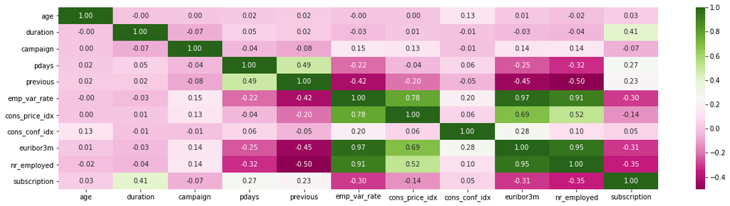

```python
plt.figure(figsize=(20, 5))
corr = subscription_dataset.corr()
sns.heatmap(corr, cmap='PiYG', annot=True, fmt=".2f", cbar=True)
plt.xticks(rotation=0)
plt.show()
```

**Summary of the findings: -**

- There is multicollinearity, because we observed multiple warm colored cells in correlation heatmap.
- In dataset we have 5 social and economic attributes, we observed strong correlation among 4 of those attributes.

  a. emp_var_rate

  b. cons_price_index

  c. euribor3m

  d. nr_employed
- Our target feature: "subscription" has strongest positive correlation with "duration". Thus, we can infer that as duration of marketing call increases, there is relatively higher likelihood of customer subscribing with the bank.
- Our target feature: "subscription" has reltively weaker correlations with: -

  a. pdays -> If the number of days contacting client from previous campaign increases, there is relaltively lower likelihood of clients not subscribing with the bank.

  b. emp_var_rate -> If the employment variation rate increases, there is relatively lower likelihood of clients subscribing with the bank. This seems to be a logical indicator because higher employment variation rate means instability in economy and loss of jobs. Thus, if there are loss of jobs, people may not have enough funds to subscribe for term deposit.

  c. euribor3m -> If the euribor3m rate increases, there is relatively lower likelihood of clients subscribing with the bank for term deposit. This seems to be a logical indicator because lower euribor3m means borrowing become cheaper and thus, clients may have interest in using the remaining funds in term deposit. However, higher euribor3m rate means borrowing becomes expensive and thus, clients may not have funds to feel interested in subscribing for term deposit.

  d. nr_employed -> If the nr_employed increases, there is relatively lower likelihood of clients subscribing with the bank for term deposit. Thus, we observed inverse relation between the two features.

**Reasons for selecting the chart type: -**

- Heatmap was used as the visual to identify correlation between different numeric features and identify which set of features have strong correlation and which set of features have weak correlation.
- Heatmap helps to visually represent the data and distinuish the strength of correlation using colors.
- It helps to get summarized understanding of the relationship between all variables of interest.

**Gestalt principles: -**

- Law of Similarity: -

[output not shown]

- Law of Pragnanz (Simplicity): -

```
a. When data is concise and simple, it easy to follow.

b. In our heatmap, we have kept precision value upto two decimal places. Thus, the data in each cell is readable, the cells are concise to read and interpret the data.

c. We have kept x axis data horizontal and this, it can be easily read left to right.

d. We have added a color scale at the right hand side of the matrix to allow easier interpretation of colors with respect to correlation score between the features.
```

**Preattentive attributes: -**

- Hue: -

  a. The intensity of each color helps us to show multiple correlationa values in the matrix effectively.

  b. Thus, as the reader of the visual we easily can infer the data from the chart based on the colors used and their relative shades.
- Information Hierarchy: -

```
a. The magnitude of values is represnted by the shades of the colors used.

b. The precision of values also allows for easier readabiliy of data and inferring the results faster.
```

### Question 2

#### Find age distribution and Plot a graph for this. And check which age group is most likely to subscribe the bank. Write the python code in the below cell to create the appropriate visual to perform the above task .

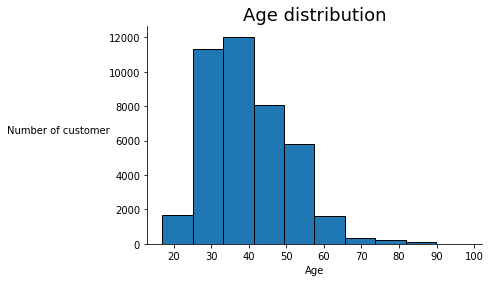

```python
#Age distribution
subscription_dataset.hist(column='age',grid=False,edgecolor='black')
plt.xlabel('Age')
plt.ylabel('Number of customer',rotation=0,labelpad=50)
plt.title('Age distribution',fontsize=18)
ax=plt.gca()
ax.spines['top'].set_visible(False)
ax.spines['right'].set_visible(False)
plt.show()
```

**Summary of the findings: -**

- We observed data distribution for age of customers is right-skewed or positively skewed.
- Thus, the mean value of age is greater than median value of age.
- The most mumber of customers are in the range of 30 to 40 years.

**Reasons for selecting the chart type: -**

- We selected Histogram chart to visualize distribution customers based on their age.
- It helps to show the comparison of distribution of age across bin size.
- It is better than bar chart because column width in histogram also signifies the size of bin.
- Bins help us to partition our values in the equal sized intervals.
- Higher length of bar for a given bin indicates greater concenteration of data points within that interval of data. Similarly, smaller length of bards given for a bin indicates lower concenteration of data points within that interval of data.
- It is inherently simple and compact chart giving our details of the data in defined scope of intention.

**Gestalt principles: -**

- Law of Closure: -

```
a. We have removed border from chart since each chart is standalone, and we have used White space to differentiate the data from other elements.

b. Law of Closure on Histogram tells that we preceive open structures as closed and regular in most places where its reasonably visible.

c. Thus, we need only two axes rather than full enclosure for Histogram to define the space in which the data appears.
```

- Law of Pragnanz (Simplicity): -

  a. We have added borders to each reactange, which facilitates to perceive bouandries betweeen adjacent bars clearly.
- Law of Continuity: -

```
a. The histogram frequency helps us visualize the the bins where frequencies increase and the bin upto to which we see the increase in frequency.

b. Similarly, we see the histogram showcasing decline in freuency from the maximum to minimum.

c. And the trend of bars in histogram show case us the order and easily interpret decline and incline in the count.
```

**Preattentive attributes: -**

- Width of edge: -

```
a. We have defined a small but easily identifiable width for each bar in the histogram which does not get over dominant but rather add more clarity when reading the chart especially when comparing adjacent bars.

b. Adding width of the edge in histogram bars make details of the chart more visible compared to absence of the same.
```

- Information hierarchy: -

```
a. We have all the data in x-axis and y-axis labels in usual readable format from left to right.

b. The heading of the chart has font size greater than other text in the chart to clearly distinguish between the two sets of text in our visual.
```

```python
age_0=list()
age_1=list()
```

```python
i=0
while(i<len(subscription_dataset['subscription'])):
    if(subscription_dataset['subscription'][i]==0):
        age_0.append(subscription_dataset['age'][i])
    elif(subscription_dataset['subscription'][i]==1):
        age_1.append(subscription_dataset['age'][i])
    i=i+1
```

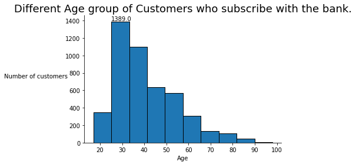

```python
plt.hist(age_1, bins=10,edgecolor='black', color='skyblue')
plt.xlabel("Age")
plt.ylabel("Number of customers",rotation=0,labelpad=50)
plt.title("Different Age group of Customers who subscribe with the bank.",fontsize=18)
y, x, _ = plt.hist(age_1, bins=10,edgecolor='black')

# Compute the max value (plt.hist returns the x and y positions of the bars)
ymax = y.max()
idx = np.where(y == ymax)[0][0]
xval = x[idx]

# Annotate the highest value
plt.gca().text(xval, ymax, ymax, ha='left', va='bottom')
ax=plt.gca()
ax.spines['top'].set_visible(False)
ax.spines['right'].set_visible(False)
plt.show()
```

**Reasons for selecting the chart type: -**

- We selected Histogram chart to visualize distribution customers who subscribed based on their age.
- It helps to show the comparison of distribution of age across bin size.
- Higher length of bar for a given bin indicates greater concenteration of data points within that interval of data. Similarly, smaller length of bards given for a bin indicates lower concenteration of data points within that interval of data.

**Gestalt principles: -**

- Law of Closure: -

```
a. We have removed border from chart since each chart is standalone, and we have used White space to differentiate the data from other elements.

b. Law of Closure on Histogram tells that we preceive open structures as closed and regular in most places where its reasonably visible.

c. Thus, we need only two axes rather than full enclosure for Histogram to define the space in which the data appears.
```

- Local of Focal Point: -

```
a. As per our requirement, we also needed to identify the age category which is most likely to subscribe. Thus, to seek immediate focus, we added a data label on the longest bar in histogram so that it immediately catches attention of value on a single bar and its absence on other bars of the histogram.
```

- Law of Pragnanz (Simplicity): -

  a. We have added borders to each reactange, which facilitates to perceive bouandries betweeen adjacent bars clearly.

**Preattentive attributes: -**

- Width of edge-color: -

```
a. We have defined a small but easily identifiable width for each bar in the histogram which does not get over dominant but rather add more clarity when reading the chart especially when comparing adjacent bars.

b. Adding width of the edge in histogram bars make details of the chart more visible compared to absence of the same.
```

- Information hierarchy: -

```
a. We have all the data in x-axis and y-axis labels in usual readable format from left to right.

b. The heading of the chart has font size greater than other text in the chart to clearly distinguish between the two sets of text in our visual.
```

### Question 3

#### Visualize number of contacts made in each month. Write the python code in the below cell to create the appropriate visual to perform the above task .

```python
data={'Month':['Jan','Feb','Mar','Apr','May','Jun','Jul','Aug','Sep','Oct','Nov','Dec'],
      'ContactCount':[0,0,0,0,0,0,0,0,0,0,0,0]
}
#print(data)
```

```python
month_contact=pd.DataFrame(data)
```

```python
i=0
while(i<len(subscription_dataset['month'])):
    if(subscription_dataset['month'][i]=='jan'):
        existingCount=month_contact.iloc[0]['ContactCount']
        newCount=existingCount+subscription_dataset['campaign'][i]
        month_contact.iat[0, 1]=newCount
    elif(subscription_dataset['month'][i]=='feb'):
        existingCount=month_contact.iloc[1]['ContactCount']
        newCount=existingCount+subscription_dataset['campaign'][i]
        month_contact.iat[1, 1]=newCount
    elif(subscription_dataset['month'][i]=='mar'):
        existingCount=month_contact.iloc[2]['ContactCount']
        newCount=existingCount+subscription_dataset['campaign'][i]
        month_contact.iat[2, 1]=newCount
    elif(subscription_dataset['month'][i]=='apr'):
        existingCount=month_contact.iloc[3]['ContactCount']
        newCount=existingCount+subscription_dataset['campaign'][i]
        month_contact.iat[3, 1]=newCount
    elif(subscription_dataset['month'][i]=='may'):
        existingCount=month_contact.iloc[4]['ContactCount']
        newCount=existingCount+subscription_dataset['campaign'][i]
        month_contact.iat[4, 1]=newCount
    elif(subscription_dataset['month'][i]=='jun'):
        existingCount=month_contact.iloc[5]['ContactCount']
        newCount=existingCount+subscription_dataset['campaign'][i]
        month_contact.iat[5, 1]=newCount
    elif(subscription_dataset['month'][i]=='jul'):
        existingCount=month_contact.iloc[6]['ContactCount']
        newCount=existingCount+subscription_dataset['campaign'][i]
        month_contact.iat[6, 1]=newCount
    elif(subscription_dataset['month'][i]=='aug'):
        existingCount=month_contact.iloc[7]['ContactCount']
        newCount=existingCount+subscription_dataset['campaign'][i]
        month_contact.iat[7, 1]=newCount
    elif(subscription_dataset['month'][i]=='sep'):
        existingCount=month_contact.iloc[8]['ContactCount']
        newCount=existingCount+subscription_dataset['campaign'][i]
        month_contact.iat[8, 1]=newCount
    elif(subscription_dataset['month'][i]=='oct'):
        existingCount=month_contact.iloc[9]['ContactCount']
        newCount=existingCount+subscription_dataset['campaign'][i]
        month_contact.iat[9, 1]=newCount
    elif(subscription_dataset['month'][i]=='nov'):
        existingCount=month_contact.iloc[10]['ContactCount']
        newCount=existingCount+subscription_dataset['campaign'][i]
        month_contact.iat[10, 1]=newCount
    elif(subscription_dataset['month'][i]=='dec'):
        existingCount=month_contact.iloc[11]['ContactCount']
        newCount=existingCount+subscription_dataset['campaign'][i]
        month_contact.iat[11, 1]=newCount
    i=i+1
```

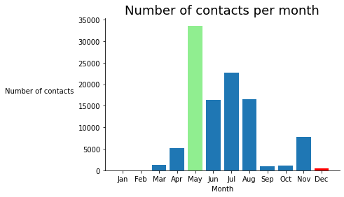

```python
colors=['#1f77b4','#1f77b4','#1f77b4','#1f77b4','lightgreen','#1f77b4','#1f77b4','#1f77b4','#1f77b4','#1f77b4','#1f77b4','red']
plt.bar(month_contact['Month'],month_contact['ContactCount'], color=colors)
plt.xlabel('Month')
plt.ylabel('Number of contacts',rotation=0,labelpad=55)
plt.title('Number of contacts per month', fontsize=18)
ax=plt.gca()
ax.spines['top'].set_visible(False)
ax.spines['right'].set_visible(False)
plt.show()
```

**Summary of the findings: -**

- Most number of contacts performed during the campaign were in May and least in December.
- We did not find any contacts performed in Januray and February.
- In first half of the year, apart from May, we observed relatively more number of contacts in June.
- In second half of the year, we observed relatively more number of contacts in July, August and November.

**Reasons for selecting the chart type: -**

- We use Bar chart for our visualization.
- Bar chart helps us to visualize different categories of data.
- The categories are on x-axis and count is on y-axis.
- Bar chart's length helps to visualize the distribution of records across various categories and allows easier interpretation of results than other charts for same use case.

**Gestalt principles: -**

- Law of Closure: -

```
a. We have removed border from chart since each chart is standalone, and we have used White space to differentiate the data from other elements.

b. Law of Closure on Bar chart tells that we preceive open structures as closed and regular in most places where its reasonably visible.

c. Thus, we need only two axes rather than full enclosure for Bar chart to define the space in which the data appears.
```

- Law of Focal Point: -

```
a. We have distinctly marked the bars with lowest and highest frequency with red and lightgreen color respectively.

b. Thus, we easily identify the months which had minimum and maximum contacts from visual interpretation.
```

**Preattentive attributes: -**

- Hue: -

```
a. We used colors to visually separate the highest and lowest values from all the categories in the bar chart.

b. It helps us to save time and effort to perform visual searching through the data.

c. The choice of color is also made significantly, such as green is chosen for indicating maximum contact in a month and red is chosen for minimum contact in a month.

d. The contrasting colors in different parts of the data helps the visual to bring out more information.
```

- Information hierarchy: -

```
a. We have all the data in x-axis and y-axis labels in usual readable format from left to right.

b. The heading of the chart has font size greater than other text in the chart to clearly distinguish between the two sets of text in our visual.
```

### Question 4

#### Categorize the data by grouping into education divisions and check which sector is more likely to subscribe. Write the python code in the below cell to create the appropriate visual to perform the above task .

```python
count_subscription_by_education = subscription_dataset.groupby('education')['subscription'].count()
#count_subscription_by_education
```

```python
education_count_sorted=count_subscription_by_education.sort_values()
#education_count_sorted
```

```python
education_count= pd.DataFrame({'education': education_count_sorted.index, 'count': education_count_sorted.values})
#education_count
```

```python
data={'Education':['UniversityDegree','ProfessionalCourse','HighSchool','Basic9y','Basic6y','Basic4y','Illiterate'],
      'Count':[0,0,0,0,0,0,0]
}
#print(data)
```

```python
education_notSubscribed=pd.DataFrame(data)
education_subscribed=pd.DataFrame(data)
```

```python
i=0
while(i<len(subscription_dataset['education'])):
    if(subscription_dataset['education'][i]=='university.degree' and subscription_dataset['subscription'][i]==0):
        existingCount=education_notSubscribed.iloc[0]['Count']
        newCount=existingCount+1
        education_notSubscribed.iat[0, 1]=newCount
    elif(subscription_dataset['education'][i]=='university.degree' and subscription_dataset['subscription'][i]==1):
        existingCount=education_subscribed.iloc[0]['Count']
        newCount=existingCount+1
        education_subscribed.iat[0, 1]=newCount
    elif(subscription_dataset['education'][i]=='high.school' and subscription_dataset['subscription'][i]==0):
        existingCount=education_notSubscribed.iloc[2]['Count']
        newCount=existingCount+1
        education_notSubscribed.iat[2, 1]=newCount
    elif(subscription_dataset['education'][i]=='high.school' and subscription_dataset['subscription'][i]==1):
        existingCount=education_subscribed.iloc[2]['Count']
        newCount=existingCount+1
        education_subscribed.iat[2, 1]=newCount
    elif(subscription_dataset['education'][i]=='basic.9y' and subscription_dataset['subscription'][i]==0):
        existingCount=education_notSubscribed.iloc[3]['Count']
        newCount=existingCount+1
        education_notSubscribed.iat[3, 1]=newCount
    elif(subscription_dataset['education'][i]=='basic.9y' and subscription_dataset['subscription'][i]==1):
        existingCount=education_subscribed.iloc[3]['Count']
        newCount=existingCount+1
        education_subscribed.iat[3, 1]=newCount
    elif(subscription_dataset['education'][i]=='professional.course' and subscription_dataset['subscription'][i]==0):
        existingCount=education_notSubscribed.iloc[1]['Count']
        newCount=existingCount+1
        education_notSubscribed.iat[1, 1]=newCount
    elif(subscription_dataset['education'][i]=='professional.course' and subscription_dataset['subscription'][i]==1):
        existingCount=education_subscribed.iloc[1]['Count']
        newCount=existingCount+1
        education_subscribed.iat[1, 1]=newCount
    elif(subscription_dataset['education'][i]=='basic.4y' and subscription_dataset['subscription'][i]==0):
        existingCount=education_notSubscribed.iloc[5]['Count']
        newCount=existingCount+1
        education_notSubscribed.iat[5, 1]=newCount
    elif(subscription_dataset['education'][i]=='basic.4y' and subscription_dataset['subscription'][i]==1):
        existingCount=education_subscribed.iloc[5]['Count']
        newCount=existingCount+1
        education_subscribed.iat[5, 1]=newCount
    elif(subscription_dataset['education'][i]=='basic.6y' and subscription_dataset['subscription'][i]==0):
        existingCount=education_notSubscribed.iloc[4]['Count']
        newCount=existingCount+1
        education_notSubscribed.iat[4, 1]=newCount
    elif(subscription_dataset['education'][i]=='basic.6y' and subscription_dataset['subscription'][i]==1):
        existingCount=education_subscribed.iloc[4]['Count']
        newCount=existingCount+1
        education_subscribed.iat[4, 1]=newCount
    elif(subscription_dataset['education'][i]=='illiterate' and subscription_dataset['subscription'][i]==0):
        existingCount=education_notSubscribed.iloc[6]['Count']
        newCount=existingCount+1
        education_notSubscribed.iat[6, 1]=newCount
    elif(subscription_dataset['education'][i]=='illiterate' and subscription_dataset['subscription'][i]==1):
        existingCount=education_subscribed.iloc[6]['Count']
        newCount=existingCount+1
        education_subscribed.iat[6, 1]=newCount
    i=i+1
```

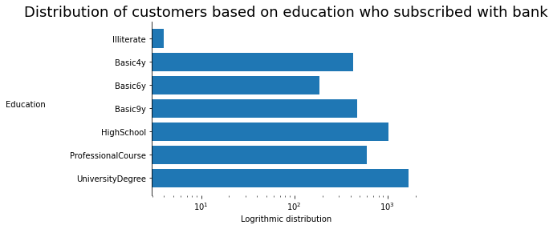

```python
plt.barh(education_subscribed['Education'],education_subscribed['Count'],log=True)
plt.ylabel('Education',rotation=0,labelpad=55)
plt.xlabel('Logrithmic distribution')
plt.title('Distribution of customers based on education who subscribed with bank', fontsize=18)
ax=plt.gca()
ax.spines['top'].set_visible(False)
ax.spines['right'].set_visible(False)
ax.spines['bottom'].set_visible(False)
plt.show()
```

**Summary of the findings: -**

- We observed among the customers who subscribed, those having educational qualification as University Degree is highest.
- We observed among the customers who subscribed, those having educational qualification as Illiterate is lowest.
- Among the customers who subscribed, those having educational qualification as High School are relatively more than those having educational qualification as Professional Course.

**Reasons for selecting the chart type: -**

- We selected Horizontal Bar chart for the visualization of customers who subscribed distributed by their educational qualification.
- The category names are lengthy and thus, if we used the normal Vertical bar chart, there would be overlapping.
- It helps to show the data in series.
- Since we want to determine the distribution of records and not the actual count, we use Lograthimic scale for our chart. This helped us to visualize data in a compact chart with count of values too large and too small are also incorporated in the distribution.
- We have arranged the categories in our chart based on order of qualification, thus, it helps us read the chart and infer if educational qualification increases, does it have impact on subscription availed by customers.

**Gestalt principles: -**

- Law of Proximity: -

```
a. We have arranged the categories on y-axis in increasing order of the level of education or level of qualification.

b. This helps us compare the trend of subscription among the people with education qualification close to each other.

c. For example: We have Basic4y, Basic6y and Basic9y qualifications in sequential order. Thus, if we are suppose to compare the successful subscription status among junior qualifications, we do not need to search them complete bar chart, rather we find them all together and in order of their level.

d. Similarly, we have High School, Professional Course and University Degree qualifications in sequential order. Thus, if we are to compare successful subscription status among senior qualifications, we can find their bars together and in sequence for easy comparison.

e. And if we were to compare successful trend of subscription across eductaional qualification of the customers, we have the data sequentially arranged and thus, there is no overhead of understanding order of qualification and rather can directly visualize the pattern to make decisions.
```

- Law of Closure: -

```
a. We have removed border from chart since each chart is standalone, and we have used White space to differentiate the data from other elements.

b. Law of Closure on Horizontal Bar chart tells that we preceive open structures as closed and regular in most places where its reasonably visible.

c. Thus, we need only two axes rather than full enclosure for Horizontal Bar chart to define the space in which the data appears.
```

- Law of Pragnanz (Simplicity): -

```
a. We have arranged the data in logical order of educational qualifications, thus, it becomes relatively easier and more readable.
```

**Preattentive attributes: -**

- Information hierarchy: -

```
a. We have all the data in x-axis and y-axis labels in usual readable format from left to right.

b. The heading of the chart has font size greater than other text in the chart to clearly distinguish between the two sets of text in our visual.
```

- Length: -

```
a. We are able to easily infer results and compare visually by using length of the bars as the comparison across different categories given there is a common base line for all the bars.

b. The length of the bars help us infer the ranking of the data and thus, infer more information visually.

c. Moreoever, where the length of bars is equal across categories, that also helps us infer that there is no correlation across the categories of the field. This is also an important information to know because it helps us to eliminate the features which may not be useful in our current interpretation of the data.
```

- Color: -

```
a. We have used common color in all bars of the Bar chart and thus, there is no extra workload for end readers to interpret the charts because we already have the category values defined on the axis.
```

### Question 5

#### Plot the chart to show the total number of clients subscribed to the deposit Write the python code in the below cell to create the appropriate visual to perform the above task .

```python
subscription_summary=subscription_dataset['subscription'].value_counts()
subscription_summary_df=pd.DataFrame({'status': subscription_summary.index, 'count': subscription_summary.values})
#subscription_summary_df
```

```python
def setLabelValue(df):
    for i in range(len(df.index)):
        plt.text(i,df.iat[i, 1],df.iat[i, 1])
```

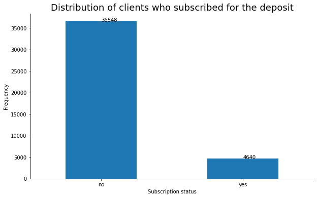

```python
ax = subscription_dataset['subscription'].value_counts().plot(kind='bar', figsize=(10, 6))
ax.set_xlabel('Subscription status')
ax.set_ylabel('Frequency')
ax.set_title('Distribution of clients who subscribed for the deposit',fontsize=18)
plt.xticks(np.arange(0,2),['no','yes'],rotation=0)
setLabelValue(subscription_summary_df)
ax=plt.gca()
ax.spines['top'].set_visible(False)
ax.spines['right'].set_visible(False)
plt.show()
```

**Summary of the findings: -**

- We observed most number of customers did not subscribe for the deposit.

  a. 36,548 out of 41,188 customers did not subscribed. -> 88.73%

  b. 4,640 out of 41,188 customers subscribed. -> 11.27%
- Thus, we can infer most of the customers did not subscribe for the deposit.

**Reasons for selecting the chart type: -**

- We selected Bar chart for our visulization of data.
- Bar Chart is effective for visualizing categorical data on x-axis and their respective counts on y-axis.
- The length of bars clearly display disriminatory distribution among the customers who subscribed for deposit or not subscribed for deposit.
- We have also added values on top of each bar to allow better readability for actual values for each category of subscription status. Thus, the Bar chart helps us infer the trend of distribution, the values on top of the bar helps us get the actual counts in each category.

**Gestalt principles: -**

- Law of Closure: -

```
a. We have removed border from chart since each chart is standalone, and we have used White space to differentiate the data from other elements.

b. Law of Closure on Bar chart tells that we preceive open structures as closed and regular in most places where its reasonably visible.

c. Thus, we need only two axes rather than full enclosure for Bar chart to define the space in which the data appears.
```

- Law of Pragnanz (Simplicity): -

```
a. We have added data labels on top of each bar, thus, along with distribution of clients who subscribed for deposit, we also get precise count which helps us to easily compute the respective percentage out of total customers.

b. Moreover the scale of increase on y-axis is of 5000, thus, it can become difficult to know the correct interpretation.

c. Thus, we have made the visualization simple to read and infer the data.
```

**Preattentive attributes: -**

- Information hierarchy: -

```
a. We have all the data in x-axis and y-axis labels in usual readable format from left to right.

b. The heading of the chart has font size greater than other text in the chart to clearly distinguish between the two sets of text in our visual.
```

- Length: -

```
a. We are able to easily infer results and compare visually by using length of the bars as the comparison across different categories given there is a common base line for all the bars.

b. The length of the bars help us infer the ranking of the data and thus, infer more information visually.
```

- Color: -

```
a. We have used common color in all bars of the Bar chart and thus, there is no extra workload for end readers to interpret the charts because we already have the category values defined on the axis.
```

# Group's choice-2 Marks

#### Frame 1 (more) question which will help in the EDA(Exploratory Data Analysis) of the given data set and answer the same using the best visual.

1. Write the question in a markdown cell
2. Below the question, in a coding cell, write the python code to create the visual to answer the question

#### Answer in markdown cells below the visual 1.Summarise your findings from the visual. 2.The reason for selecting the chart type you did. 3.Mention the pre-attentive attributes used.(atleast 2) 4.Mention the gestalt principles used.(atleast 2)

**Group's own question**

Categorize the data by grouping into previous campaign outcome (poutcome) and check if it has impact on current campaign's result.

```python
count_subscription_by_poutcome = subscription_dataset.groupby('poutcome')['subscription'].count()
#count_subscription_by_poutcome
```

```python
poutcome_count_sorted=count_subscription_by_poutcome.sort_values()
#poutcome_count_sorted
```

```python
poutcome_count= pd.DataFrame({'poutcome': poutcome_count_sorted.index, 'count': poutcome_count_sorted.values})
#poutcome_count
```

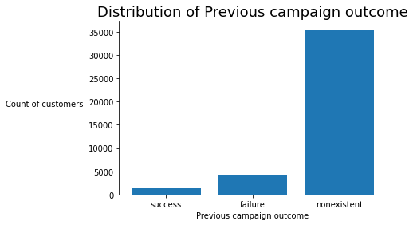

```python
plt.bar(poutcome_count['poutcome'],poutcome_count['count'])
plt.ylabel('Count of customers',rotation=0, labelpad=55)
plt.xlabel('Previous campaign outcome')
plt.title('Distribution of Previous campaign outcome', fontsize=18)
ax=plt.gca()
ax.spines['top'].set_visible(False)
ax.spines['right'].set_visible(False)
plt.show()
```

**Summary of the findings: -**

- We observed the distribution for previous campagign outcome is highest for nonexistent.
- Among success and failure, we observed higher count of records where previous campaign's outcome was failure.

**Reasons for selecting the chart type: -**

- We used Bar chart for the visualization.
- Bar chart is useful for visualizing the categories in dataset along with their respective frequency.
- In our visual, the categories are limited and thus, we could use a Vertical Bar Chart.
- The length of the Bar chart helps to visually interpret the count of records for different categories in the dataset.

**Gestalt principles: -**

- Law of Closure: -

```
a. We have removed border from chart since each chart is standalone, and we have used White space to differentiate the data from other elements.

b. Law of Closure on Bar chart tells that we preceive open structures as closed and regular in most places where its reasonably visible.

c. Thus, we need only two axes rather than full enclosure for Bar chart to define the space in which the data appears.
```

- Law of Pragnanz (Simplicity): -

```
a. We have arranged the categories in logical and systematic order to make it easily readable.
```

**Preattentive attributes: -**

- Information hierarchy: -

```
a. We have all the data in x-axis and y-axis labels in usual readable format from left to right.

b. The heading of the chart has font size greater than other text in the chart to clearly distinguish between the two sets of text in our visual.
```

- Length: -

```
a. We are able to easily infer results and compare visually by using length of the bars as the comparison across different categories given there is a common base line for all the bars.

b. The length of the bars help us infer the ranking of the data and thus, infer more information visually.
```

- Color: -

```
a. We have used common color in all bars of the Bar chart and thus, there is no extra workload for end readers to interpret the charts because we already have the category values defined on the axis.
```

```python
data={'Poutcome':['Success','Failure'],'Count':[0,0]}
#print(data)
```

```python
poutcome_subscribed=pd.DataFrame(data)
```

```python
i=0
while(i<len(subscription_dataset['poutcome'])):
    if(subscription_dataset['poutcome'][i]=='success' and subscription_dataset['subscription'][i]==1):
        existingCount=poutcome_subscribed.iloc[0]['Count']
        newCount=existingCount+1
        poutcome_subscribed.iat[0, 1]=newCount
    elif(subscription_dataset['poutcome'][i]=='failure' and subscription_dataset['subscription'][i]==1):
        existingCount=poutcome_subscribed.iloc[1]['Count']
        newCount=existingCount+1
        poutcome_subscribed.iat[1, 1]=newCount
    i=i+1
```

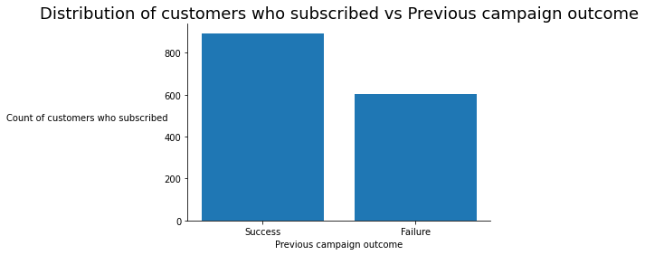

```python
plt.bar(poutcome_subscribed['Poutcome'],poutcome_subscribed['Count'])
plt.ylabel('Count of customers who subscribed',rotation=0,labelpad=85)
plt.xlabel('Previous campaign outcome')
plt.title('Distribution of customers who subscribed vs Previous campaign outcome', fontsize=18)
ax=plt.gca()
ax.spines['top'].set_visible(False)
ax.spines['right'].set_visible(False)
plt.show()
```

**Summary of the findings: -**

- If Previous campaign outcome is success, then there is relatively higher chance of customers subscribing with the bank for term deposit.

**Reasons for selecting the chart type: -**

- We use Bar chart for visualization.
- The Bar chart helps to clearly visualize the categorical data along with their respective frequency.
- Since we have very limited set of categories and the length of their names is short, we could use Vertical Bar Chart.

**Gestalt principles: -**

- Law of Closure: -

```
a. We have removed border from chart since each chart is standalone, and we have used White space to differentiate the data from other elements.

b. Law of Closure on Bar chart tells that we preceive open structures as closed and regular in most places where its reasonably visible.

c. Thus, we need only two axes rather than full enclosure for Bar chart to define the space in which the data appears.
```

- Law of Similarity: -

```
a. All the bars in Bar chart are of same color, and thus, there is no cognitive load of understanding of colors and rather the focus of interpretation of graph is based on length of bars and their comparisons.
```

**Preattentive attributes: -**

- Information hierarchy: -

```
a. We have all the data in x-axis and y-axis labels in usual readable format from left to right.

b. The heading of the chart has font size greater than other text in the chart to clearly distinguish between the two sets of text in our visual.
```

- Length: -

```
a. We are able to easily infer results and compare visually by using length of the bars as the comparison across different categories given there is a common base line for all the bars.

b. The length of the bars help us infer the ranking of the data and thus, infer more information visually.
```

- Color: -

```
a. We have used common color in all bars of the Bar chart and thus, there is no extra workload for end readers to interpret the charts because we already have the category values defined on the axis.
```

# ************ END OF ASSIGNMENT ****************